# *Immigration, Offshoring and American Jobs* - A replication of Ottaviano, Peri and Wright (2013)

## Notebook content

1. Research Question
2. Motivation
3. The Theoretical Model

   **3.1 Description of the Model**

   **3.2 Predictions of the Model**
4. The Econometric Model

   **4.1 Displacement Effect**

   **4.2 Productivity Effect**
5. Reproduction of the Results

   **5.1 Effects of Immigration and Offshoring on Employment Shares**

   **5.2 Effects of Immigration and Offshoring on Total Employment**
6. Conclusion

## 1. Research Question

In their paper [*“Immigration, Offshoring and American Jobs”*](https://www.aeaweb.org/articles?id=10.1257/aer.103.5.1925), published in 2013, Gainmarco Ottaviano, Giovanni Peri and Greg Wright analyze the impact of immigration and offshoring on employment in the American manufacturing sector. They find that immigration and offshoring have a positive effect on total emplyoment in the US manufacturing sector. In the following Notebook, first, their theoretical model is described, then some descriptive statistics are provided and finally some of their empirical results are replicated and presented. In particular, it is evaluated what effect an decrease in the costs of immigrant and offshoring labor have on the shares of domestic, immigrant and offshore workers as well as on the total employment level.

## 2. Motivation

It is a widespread believe that increases in offshoring and immigration are credited with a demise of manufacturing jobs of American natives: asked whether the developments of offshoring and immigration have done more to help or to hurt American workers, 77% of the Americans claim that offshoring has hurt them and 55% say that immigration has hurt them ([PewReseachCenter 2006](http://www.pewsocialtrends.org/2006/08/30/american-work-life-is-worsening-but-most-workers-still-content/)). The newly elected American president, Donald Trump also has this vision on Migration: he wants to put America first, meaning that American citizens will get the jobs first. ([Trump pence, 2016](https://www.donaldjtrump.com/policies/immigration)) Thus, it is an interesting and important topic to investigate. Moreover, there are several recent papers focusing either on the effects of immigration or on the effects of offshoring on the American labor market. However, there is no paper providing a combined empirical analysis of these two aspects of globalisation on employment. [Ottaviano et al.](https://www.aeaweb.org/articles?id=10.1257/aer.103.5.1925) claim that "[...] the joint investigation of the interactions among these three groups of workers is useful in order to improve our understanding of the impact of globalization on the US labor market and, in particular to answer to hotly debated questions. First, how do declines in offshoring and immigration costs affect the employment of native workers? Second, what kinds of jobs suffer or benefit the most form the competition created by offshore and immigrant wokers?" In the following, it is focused on the results respective to the first of these questions.

## 3. The Theoretical Model

### 3.1 Description of the Model

In advance of developing their theoretical model, Ottaviano et al. present several descriptive statistics about employment of low skilled workers in different industries of the US manufacturing sector from 2000 to 2007. These statistics show that there is no correlation between the shares of native and immigrant employment and a negative correlation between the shares of native and offshore employment as well as between the shares of immigrant and offshore employment.

```
Axes(0.125,0.125;0.775x0.775)
```

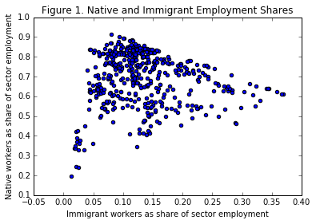

```python
%matplotlib inline
import pandas as pd
import matplotlib.pyplot as plt #import the necessary packages

data = pd.read_csv("/Users/Sietske/Documents/data00_07.csv") #import the data

output= data.plot(kind='scatter',x='share_immi',y='share_nat') #creating the scatterplot
plt.title("Figure 1. Native and Immigrant Employment Shares") #assigning a title to the scatterplot
plt.xlabel("Immigrant workers as share of sector employment") #labeling of the axis
plt.ylabel("Native workers as share of sector employment")

print output
```

```
Axes(0.125,0.125;0.775x0.775)
```

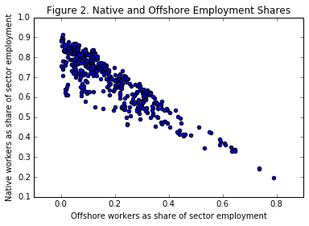

```python
%matplotlib inline
import pandas as pd
import matplotlib.pyplot as plt

data = pd.read_csv("/Users/Sietske/Documents/data00_07.csv")

output= data.plot(kind='scatter',x='share_off',y='share_nat')
plt.title("Figure 2. Native and Offshore Employment Shares")
plt.xlabel("Offshore workers as share of sector employment")
plt.ylabel("Native workers as share of sector employment")

print output
```

```
Axes(0.125,0.125;0.775x0.775)
```

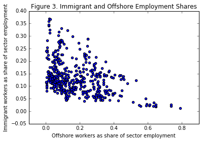

```python
%matplotlib inline
import pandas as pd
import matplotlib.pyplot as plt

data = pd.read_csv("/Users/Sietske/Documents/data00_07.csv")

output= data.plot(kind='scatter',x='share_off',y='share_immi')
plt.title("Figure 3. Immigrant and Offshore Employment Shares")
plt.xlabel("Offshore workers as share of sector employment")
plt.ylabel("Immigrant workers as share of sector employment")

print output
```

Moreover, it is revealed that the representation of immigrant workers is higher in occupations with lower complexity. Furthermore, changes of the share of immigrants are observed to have no effect on the complexity of native jobs and jobs of offshore workers, while a change in the share of offshore workers affects the complexity level of immigrant tasks in a negative way and the complexity level of native tasks in a positive way.  
These observations are interpreted in the following way: while natives compete with offshore workers and offshore workers compete with immigrants, there is no competition between immigrants and natives. This can be explained by the specialization of the three groups on different kinds of tasks: Natives specialize on tasks with high complexity, immigrants on tasks with low complexity and offshore workers on tasks with intermediate complexity. Based on this interpretation, the assumptions of the model are specified.

**Table 1. Exogenous parameters**

| Symbol | Definition |
| --- | --- |
| $w$ | Wage native workers |
| $\tilde{w}$ | Wage immigrant worker |
| $w^*$ | Wage offshore worker |
| $a_L$ | Unit labor requirement |
| $\delta$ | Foregone productivity M |
| $\tau(i)$ | Unit input requirement M |
| $\beta t(i)$ | Unit input requirement O |

**Table 2. Endogenous parameters**

| Symbol | Definition |
| --- | --- |
| $c_D(i)$ | Marginal costs producing task $i$ employing native workers |
| $c_M(i)$ | Marginal costs producing task $i$ employing migrant workers |
| $c_O(i)$ | Marginal costs producing task $i$ employing offshore workers |

Ottaviano et al. developed a partial equilibrium model. This theoretical model describes the distribution of jobs among native, immigrant and offshore employees depending on the complexity of the task, while only manufacturing tasks, requiring low skills, are considered.  
Natives, immigrants and offshore workers are considered to be perfectly substitutable. Thus, the worker entailing the lowest marginal cost will perform a task in the equilibrium. The marginal costs for natives are determined only by their wage $w$, while the marignal production costs of immigrant and offshore workers are composed by their wages $\tilde{w}$, $w^*$, frictional costs $\delta$, $\beta$ and task specific costs $\tau(i)$, $t(i)$.

For all three groups of workers the labor unit requirment $a_L$ is the same. This results in the following marginal production costs:

$c_D=wa_L$,

$c_M=\tilde{w}\tau(i)a_L=\delta w^*\tau(i)a_L$

$c_O=w^*\beta t(i)a_L$.

Moreover, Ottaviano et al. specified sufficient conditions on the characteristics of the components of the marginal costs for the three groups of workers to specialize in high, low and medium complexity tasks. Thus, a marginal immigrant task $I_{MO}$ as well as a marginal offshore task $I_{NO}$ exists.  
Hence, the marginal costs for the three types of workers depending on the complexity of the tasks and the resulting assignment of the tasks to natives, immigrants and offshore workers can be illustrated like this:

**Figure 4.**

[figure not shown]

From this figure it is clear that $I_{MO}$ and $I_{NO}$ can be specified as follows:

$I_{MO}$ is reached when $c_M(i)$ = $c_O(i)$, so if

$\delta w^*\tau(i)a_L$ = $w^*\beta t(i)a_L$

$I_{NO}$ is reached when $c_D$ = $c_O(i)$, so if

$wa_L$ = $w^*\beta t(i)a_L$

```python
# Exogenous parameters
w = 2 # wage native workers
w_star = 1.5 #wage offshore worker
a_L = 1.2 # unit labor requirement
delta = 1.3 # foregone productivity migrant worker
tau = 1.6*i # unit input requirement by migrant worker
beta_t = 1.4*i # unit input requirement by offshore worker
w_tilde = delta*w_star # wage immigrant workers
```

The values of the exogenous parameters are set at a particular value to that they suit the descriptions of the model. From this, $I_{MO}$ and $I_{NO}$ can be calcuated. After this, the effect of an increase in $\delta$ will be addressed.

```python
# Endogenous varables

c_d = w*a_L
c_m = delta*w_star*tau*a_L
c_o = w_star*beta_t
```

```python
# When c_m = c_o
i = (delta*w_star*tau/i*a_L)/(w_star*beta_t/i)
print i
```

```
1.78285714286
```

```python
# When c_d = c_o

i = (w*a_L)/(w_star*beta_t/i)

print i
```

```
2.03755102041
```

In the following analysis an increase in $\delta$ will be addressed on the different values of $i$

```python
# Exogenous parameters
w = 2 # wage native workers
w_star = 1.5 #wage offshore worker
a_L = 1.2 # unit labor requirement
delta = 1.8 # foregone productivity migrant worker
tau = 1.6*i # unit input requirement by migrant worker
beta_t = 1.4*i # unit input requirement by offshore worker
w_tilde = delta*w_star # wage immigrant workers
```

```python
# Endogenous varables

c_d = w*a_L
c_m = delta*w_star*tau*a_L
c_o = w_star*beta_t
```

```python
# When c_m = c_o
i = (delta*w_star*tau/i*a_L)/(w_star*beta_t/i)
print i
```

```
2.46857142857
```

```python
# When c_d = c_o

i = (w*a_L)/(w_star*beta_t/i)

print i
```

```
2.8212244898
```

There is an increase in both the equilibrium values of the task index. This means, that for a larger value of i, immigrant workers have the lowest marginal cost. This means that the offshore worker and native worker will not benefit from a increase in $\delta$.

It is important to mention that this analysis is just a calibration of the model where the values of the parameters are set to a particular value. Therefore there is no empirical conclusion possible.

### 3.2 Predictions of the Model

Based on this model, predictions can be made about the effects of changes in the sector specific cost parameters $\delta$ an $\beta$, which are referred to as changes in the costs of immigration and offshoring, on employment shares, employment levels and task assignment. As mentioned before, the focus here will be on the effects on employment shares and employment levels. Lower immigration costs are expected to reduce the share of offshore workers, to have no effect on the share of natives and to increase the share of immigrants. Lower offshoring costs are expected to reduce the shares of natives and immigrants, and to increase the share of offshore workers. Moreover, as a consequence of declining offshoring or immigration costs, the demand for workers is expected to rise, so that an increase in the total sector employment is expected.

## 4. The Econometric Model

### 4.1 Displacement effect

First, in order to explore the degree of direct competition between the three groups of workers, also referred to as the “displacement effect”, the effect of a change in immigration and offshoring costs on the different employment shares is estimated. Therefore, the following regressions are estimated:

Equation (1) $$ {s_D}_{st}=\phi_{s}^{D}+\phi_{t}^{D}+b_{DO}({s_O}_{st})+b_{DM}({s_M}_{st})+\epsilon_{st}^{D} $$
Equation (2) $$ {s_M}_{st}=\phi_{s}^{M}+\phi_{t}^{M}+b_{MO}({s_O}_{st})+\epsilon_{st}^{M} $$
Equation (3) $$ {s_O}_{st}=\phi_{s}^{O}+\phi_{t}^{O}+b_{OM}({s_M}_{st})+\epsilon_{st}^{O} $$

Here ${s_D}_{st}$, ${s_M}_{st}$ and ${s_O}_{st}$ are the shares of domestic, immigrant and offshore workers by industry $s$ and year $t$. $\phi_{s}$ are industry fixed effects and $\phi_{t}$ are time fixed effects. $\epsilon_{st}$ are potentially serially correlated standard errors.

### 4.2 Productivity effect

Second, the effect of changes in immigration and offshoring costs on the total employment level, also referred to as the “productivity effect”, is estimated with the following regression:

Equation (4) $$ {N_L}_{st}=\phi_{s}^{L}+\phi_{t}^{L}+B_{LO}({s_O}_{st})+B_{LM}({s_M}_{st})+\epsilon_{st}^L $$

Here ${N_L}_{st}$ is the logarithm of the total employment level.

The productivity effect claims that because of lower costs for hiring immigrants or offshore workers total costs decline, which improves the efficiency of production and therefore induces an increased demand for all worker types.

## 5. Reproduction of the Results

### 5.1 Effects of Immigration and Offshoring on Employment Shares

Before the regressions of interest can be run, the data must be prepared. Therefore, first, the dataset that contains the employment data for natives and immigrants is used. It needs to be merged with the dataset containing the data on the instrument for the share of immigrants ${(Imputed_{s_M}})_{st}$, and with a dataset with information about the employment of offshore workers. All these datasets contain the same year and industry variables, thus they can be merged by them. Only employment in foreign affiliates of US parent companies is considered, not included is employment by foreign subcontractors (also called arm´s length offshoring). Therefore, the variables emp armemp and totemp get dropped. This dataset gets merged with a dataset containing the instrument for the share of offshore employment. After that the shares of employment get constructed, while for natives and immigrant workers only workers with high school diploma or lower education are considered. This dataset can be used for the regressions of the "productivity effect" as well.

```python
import numpy as np
import pandas as pd
import statsmodels.formula.api as sm #import of the required packages

data = pd.read_csv("/Users/Sietske/Documents/data00_07.csv") #import the data

result= sm.ols(formula="share_nat ~ share_off", data=data).fit() #running the OLS

print(result.params)

print(result.summary())
```

```
Intercept    0.832300
share_off   -0.807742
dtype: float64
                            OLS Regression Results
==============================================================================
Dep. Variable:              share_nat   R-squared:                       0.797
Model:                            OLS   Adj. R-squared:                  0.796
Method:                 Least Squares   F-statistic:                     1811.
Date:                Thu, 12 Jan 2017   Prob (F-statistic):          5.72e-162
Time:                        15:17:06   Log-Likelihood:                 648.39
No. Observations:                 464   AIC:                            -1293.
Df Residuals:                     462   BIC:                            -1285.
Df Model:                           1
Covariance Type:            nonrobust
==============================================================================
                 coef    std err          t      P>|t|      [95.0% Conf. Int.]
------------------------------------------------------------------------------
Intercept      0.8323      0.004    192.947      0.000         0.824     0.841
share_off     -0.8077      0.019    -42.561      0.000        -0.845    -0.770
==============================================================================
Omnibus:                       75.941   Durbin-Watson:                   1.496
Prob(Omnibus):                  0.000   Jarque-Bera (JB):              110.566
Skew:                          -1.108   Prob(JB):                     9.79e-25
Kurtosis:                       3.898   Cond. No.                         7.03
==============================================================================

Warnings:
[1] Standard Errors assume that the covariance matrix of the errors is correctly specified.
```

```python
import numpy as np
import pandas as pd
import statsmodels.formula.api as sm #import of the required packages

data = pd.read_csv("/Users/helenehellmuth/Downloads/Uni/Python Assignment/data00_07.csv") #import the data

result= sm.ols(formula="share_nat ~ share_immi", data=data).fit() #running the OLS

print(result.params)
```

```
Intercept     0.699377
share_immi   -0.054629
dtype: float64
```

```python
import numpy as np
import pandas as pd
import statsmodels.formula.api as sm #import of the required packages

data = pd.read_csv("/Users/helenehellmuth/Downloads/Uni/Python Assignment/data00_07.csv") #import the data

result= sm.ols(formula="share_immi ~ share_off", data=data).fit() #running the OLS

print(result.params)
```

```
Intercept    0.167700
share_off   -0.192258
dtype: float64
```

```python
import numpy as np
import pandas as pd
import statsmodels.formula.api as sm #import of the required packages

data = pd.read_csv("/Users/helenehellmuth/Downloads/Uni/Python Assignment/data00_07.csv") #import the data

result= sm.ols(formula="share_off ~ share_off", data=data).fit() #running the OLS

print(result.params)
```

```
Intercept   -1.045171e-16
share_off    1.000000e+00
dtype: float64
```

The results of the regressions above are deviating from the results found in the paper of Ottaviano, Peri and Wright. This is due to the fact, that the original regressions are two stage least square (2SLS) regressions using instruments for the shares of immigrant and offshore employment. Furthermore, in these regressions are industry and year fixed effects. To run such regressions, Python unfortunately is not a suited tool, because it does not have these statistical software features to make this possible.

**Table 3.**

| Specifications | Native share of employment | Native share of employment | Immigrant share of employment | Offshore share of employment |  |
| --- | --- | --- | --- | --- | --- |
| Immigrant share of employment |  | -0.47 |  | -0.53 |  |
| Offshore share of employment | -0.79** |  | -0.29** |  |  |

The Table above shows the original results of the paper. The 2SLS estimates reveal that, as predicted by the model, offshoring has a negative and highly significant effect on the share of native employment as well as on the share of immigrant employment. This means that if offshoring gets cheaper, task formerly performed by immigrants and natives are now performed by offshore workers and thus their share increases relative to the shares of immigrants and natives. Immigration has no significant effect on the share of native employment, which is in accordance with the predictions of the theoretical model. This means that immigrants do not take away any tasks of natives. The effect of immigration on the share of offshore workers is negative, as predicted by the model, but marginally not significant.

### 5.2 Effects of Immigration and Offshoring on Total Employment

Second, the effect of changes in immigration and offshoring costs on the total level of employment is considered. In order to gain information about the extent of the “productivity effect”, equation (4) is estimated. Because of the collinearity of the shares of immigrants and offshore workers two separate equations are estimated. This is done by 2SLS. ${(Imputed_{s_M}})_{st}$ and $(Tariffs)_{st}$ are used as instruments for the shares of immigrants and offshore workers. Industry and time fixed effects are included in all regressions. The reported standard errors are heteroscedasticity robust.

```python
import numpy as np
import pandas as pd
import statsmodels.formula.api as sm #import of the required packages

data = pd.read_csv("/Users/helenehellmuth/Downloads/Uni/Python Assignment/data00_07.csv") #import the data

result= sm.ols(formula="empl_total ~ share_immi", data=data).fit() #running the OLS

print(result.params)
```

```
Intercept     2.220147e+05
share_immi    1.072202e+06
dtype: float64
```

```python
import numpy as np
import pandas as pd
import statsmodels.formula.api as sm #import of the required packages

data = pd.read_csv("/Users/helenehellmuth/Downloads/Uni/Python Assignment/data00_07.csv") #import the data

result= sm.ols(formula="empl_total ~ share_off", data=data).fit() #running the OLS

print(result.params)
```

```
Intercept    435349.098500
share_off   -399211.404735
dtype: float64
```

Here the same problem as above occurs: Python is not the suited tool to run 2SLS regressions with fixed effects. Here only a simple OLS was runned, which leads to different results. Therefore, the original results are showed below in the table.

**Table 4.**

| Specifications | ln(total employment) | ln(total emplyoment) |
| --- | --- | --- |
| Immigrant share of employment |  | 3.87** |
| Offshore share of employment | 1.71** |  |

This table shows the results as presented in the original paper. The 2SLS estimates presented reveal that increases in the share of immigrants as well as in the share of offshore workers have a positive and significant effect on total employment. A 1% increase in the share of offshore workers is expected to lead to a 1.71% increase of total employment and a 1% increase in the share of immigrant workers to a 3.87% increase in total employment.

## 6. Conclusion

In this Notebook, it was tried to replicate some results of a paper by Ottaviano, Peri and Wright called "Immigration, Offshoring and American Jobs". Therefore, first their theoretical model was described, then some descriptive statistics were provided and finally some of their empirical results get replicated and presented. In particular, it was evaluated what effect an decrease in the costs of immigrant and offshoring labor have on the shares of domestic, immigrant and offshore workers as well as on the total employment level. Unfortunately, it was not possible to replicate the results in an appropriated manner, due to the fact, that Python is not mainly a statistical software like STATA. However, this Notebook provides an idea about what they are doing. Moreover, the included tabels show the results of the original paper, which show that there is a positive effect of lower immigration and offshoring costs on total employment and thus immigration and offshoring cannot be considered to bring harm for native employees.